# Modularity Analysis on the Karate Club Graph

**DSC212: Graph Theory Module**

## Abstract

This notebook implements spectral modularity-based community detection on the classic Zachary's Karate Club network. We use recursive bisection based on the leading eigenvector of the modularity matrix to discover multiple communities, and track how node centrality metrics evolve as communities are identified.

## Attribution

The modularity objective, modularity matrix B, and spectral bipartition method are based on:

**Newman, M. E. J. (2006). "Modularity and community structure in networks." PNAS 103(23):8577–8582.**

```python
# Import required libraries
import numpy as np
import networkx as nx
import matplotlib.pyplot as plt
import matplotlib.colors as mcolors
from scipy.linalg import eigh
import warnings
warnings.filterwarnings('ignore')

# Set random seed for reproducibility
np.random.seed(42)
```

## 1. Load the Karate Club Graph

The Karate Club graph is available in NetworkX. It contains 34 nodes representing club members and 78 edges representing social interactions.

```python
# Load the Karate Club graph
G = nx.karate_club_graph()
n = G.number_of_nodes()
m = G.number_of_edges()

print(f"Karate Club Graph: {n} nodes, {m} edges")
print(f"\nNodes represent club members, edges represent social interactions.")
print(f"The club split into two factions led by Mr. Hi (node 0) and the President (node 33).")
```

```
Karate Club Graph: 34 nodes, 78 edges

Nodes represent club members, edges represent social interactions.
The club split into two factions led by Mr. Hi (node 0) and the President (node 33).
```

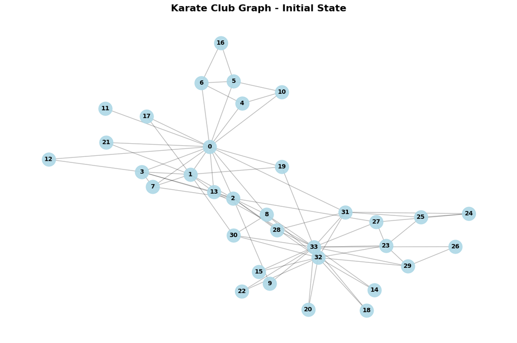

```python
# Visualize the original graph
plt.figure(figsize=(12, 8))
pos = nx.spring_layout(G, seed=42)  # Fixed layout for consistency across iterations
nx.draw_networkx_nodes(G, pos, node_color='lightblue', node_size=500, alpha=0.9)
nx.draw_networkx_edges(G, pos, alpha=0.3)
nx.draw_networkx_labels(G, pos, font_size=10, font_weight='bold')
plt.title('Karate Club Graph - Initial State', fontsize=16, fontweight='bold')
plt.axis('off')
plt.tight_layout()
plt.show()
```

## 2. Implement Modularity Matrix Computation

The modularity matrix is defined as: $$B = A - \frac{k k^\top}{2m}$$

where:

- $A$ is the adjacency matrix
- $k$ is the degree vector
- $m$ is the number of edges

```python
def compute_modularity_matrix(G, nodes=None):
    """
    Compute the modularity matrix B for a graph or subgraph.

    Parameters:
    -----------
    G : networkx.Graph
        The input graph
    nodes : list or None
        If provided, compute B for the subgraph induced by these nodes.
        Otherwise, compute for the entire graph.

    Returns:
    --------
    B : numpy.ndarray
        The modularity matrix
    node_list : list
        The ordered list of nodes corresponding to matrix rows/columns
    """
    # Use full graph if no nodes specified
    if nodes is None:
        nodes = list(G.nodes())

    # Create subgraph if needed
    if len(nodes) < G.number_of_nodes():
        subG = G.subgraph(nodes)
    else:
        subG = G

    # Get adjacency matrix and degree vector
    node_list = list(nodes)
    A = nx.to_numpy_array(subG, nodelist=node_list)
    k = np.array([subG.degree(node) for node in node_list])

    # Total edges in the FULL graph (important: use original graph's m)
    m = G.number_of_edges()

    # Compute modularity matrix: B = A - (k * k^T) / (2m)
    B = A - np.outer(k, k) / (2 * m)

    return B, node_list
```

## 3. Implement Spectral Bipartition

The spectral bipartition algorithm:

1. Compute the leading eigenvector $u_1$ of the modularity matrix $B$
2. Check if the leading eigenvalue $\lambda_1 > 0$
3. If yes, split nodes by the sign of entries in $u_1$
4. If no, the community cannot be split further

```python
def spectral_bipartition(G, nodes):
    """
    Attempt to split a community using spectral bipartition.

    Parameters:
    -----------
    G : networkx.Graph
        The full graph
    nodes : list
        The nodes in the community to split

    Returns:
    --------
    split : bool
        True if split is beneficial (lambda_1 > 0), False otherwise
    community1 : list
        Nodes assigned to first community (if split is True)
    community2 : list
        Nodes assigned to second community (if split is True)
    lambda_1 : float
        The leading eigenvalue
    """
    # Compute modularity matrix for this community
    B, node_list = compute_modularity_matrix(G, nodes)

    # Compute eigenvalues and eigenvectors
    # Use eigh for symmetric matrices (more efficient and stable)
    eigenvalues, eigenvectors = eigh(B)

    # Get leading eigenvalue and eigenvector (largest eigenvalue)
    idx = np.argmax(eigenvalues)
    lambda_1 = eigenvalues[idx]
    u_1 = eigenvectors[:, idx]

    # Check stopping criterion
    if lambda_1 <= 1e-10:  # Use small tolerance for numerical stability
        return False, None, None, lambda_1

    # Split by sign of eigenvector entries
    community1 = [node_list[i] for i in range(len(node_list)) if u_1[i] > 0]
    community2 = [node_list[i] for i in range(len(node_list)) if u_1[i] <= 0]

    # Ensure both communities are non-empty
    if len(community1) == 0 or len(community2) == 0:
        return False, None, None, lambda_1

    return True, community1, community2, lambda_1
```

## 4. Implement Recursive Bisection

Recursively apply spectral bipartition to discover multiple communities.

```python
def recursive_bisection(G, pos, initial_communities=None):
    """
    Perform recursive spectral bisection to detect multiple communities.

    Parameters:
    -----------
    G : networkx.Graph
        The input graph
    pos : dict
        Fixed node positions for visualization
    initial_communities : list of lists or None
        Initial community structure (defaults to all nodes in one community)

    Returns:
    --------
    iterations : list of dicts
        Each dict contains:
        - 'communities': list of node lists
        - 'metrics': dict of metric values for each node
        - 'split_info': information about the split performed
    """
    # Initialize with all nodes in one community
    if initial_communities is None:
        communities = [list(G.nodes())]
    else:
        communities = initial_communities.copy()

    iterations = []
    iteration = 0

    # Store initial state
    metrics = compute_all_metrics(G)
    iterations.append({
        'iteration': iteration,
        'communities': [c.copy() for c in communities],
        'metrics': metrics,
        'split_info': 'Initial state: all nodes in one community',
        'lambda_1': None
    })

    # Visualize initial state
    visualize_communities(G, pos, communities, iteration, 'Initial state')

    # Keep splitting until no more beneficial splits exist
    while True:
        split_occurred = False

        # Try to split each community
        new_communities = []
        for i, community in enumerate(communities):
            # Only try to split communities with more than 1 node
            if len(community) <= 1:
                new_communities.append(community)
                continue

            # Attempt spectral bipartition
            can_split, comm1, comm2, lambda_1 = spectral_bipartition(G, community)

            if can_split:
                # Split occurred
                new_communities.append(comm1)
                new_communities.append(comm2)
                split_occurred = True
                iteration += 1

                # Store iteration data
                metrics = compute_all_metrics(G)
                split_info = f"Split community {i} (size {len(community)}) into {len(comm1)} and {len(comm2)} nodes (λ₁={lambda_1:.4f})"
                iterations.append({
                    'iteration': iteration,
                    'communities': [c.copy() for c in new_communities],
                    'metrics': metrics,
                    'split_info': split_info,
                    'lambda_1': lambda_1
                })

                # Visualize after split
                visualize_communities(G, pos, new_communities, iteration, split_info)

                break  # Restart the loop with new communities
            else:
                # Cannot split this community
                new_communities.append(community)

        communities = new_communities

        # Stop if no splits occurred in this round
        if not split_occurred:
            break

    print(f"\nRecursive bisection complete. Found {len(communities)} communities in {iteration} iterations.")
    return iterations
```

## 5. Compute Node Centrality Metrics

We compute four standard centrality and cohesion metrics:

1. **Degree centrality**: Fraction of nodes directly connected
2. **Betweenness centrality**: How often a node lies on shortest paths
3. **Closeness centrality**: Inverse of average shortest-path distance
4. **Clustering coefficient**: Fraction of neighbors that are connected

```python
def compute_all_metrics(G):
    """
    Compute all centrality and cohesion metrics for each node.

    Parameters:
    -----------
    G : networkx.Graph
        The input graph

    Returns:
    --------
    metrics : dict
        Dictionary with keys 'degree', 'betweenness', 'closeness', 'clustering'
        Each value is a dict mapping node_id -> metric_value
    """
    metrics = {
        'degree': nx.degree_centrality(G),
        'betweenness': nx.betweenness_centrality(G),
        'closeness': nx.closeness_centrality(G),
        'clustering': nx.clustering(G)
    }
    return metrics
```

## 6. Visualization Functions

```python
def visualize_communities(G, pos, communities, iteration, title_suffix):
    """
    Visualize the graph with communities colored differently.

    Parameters:
    -----------
    G : networkx.Graph
        The graph to visualize
    pos : dict
        Node positions
    communities : list of lists
        Each list contains nodes in a community
    iteration : int
        Iteration number
    title_suffix : str
        Additional text for the title
    """
    plt.figure(figsize=(14, 9))

    # Define colors for communities
    colors = list(mcolors.TABLEAU_COLORS.values())
    if len(communities) > len(colors):
        colors = colors * (len(communities) // len(colors) + 1)

    # Draw each community with a different color
    for idx, community in enumerate(communities):
        nx.draw_networkx_nodes(G, pos, nodelist=community,
                               node_color=[colors[idx]],
                               node_size=500, alpha=0.9,
                               label=f'Community {idx+1} ({len(community)} nodes)')

    # Draw edges and labels
    nx.draw_networkx_edges(G, pos, alpha=0.2)
    nx.draw_networkx_labels(G, pos, font_size=9, font_weight='bold')

    plt.title(f'Iteration {iteration}: {title_suffix}', fontsize=14, fontweight='bold')
    plt.legend(loc='upper left', fontsize=10)
    plt.axis('off')
    plt.tight_layout()
    plt.show()
```

## 7. Run Recursive Bisection

```
Starting recursive spectral bisection...
```

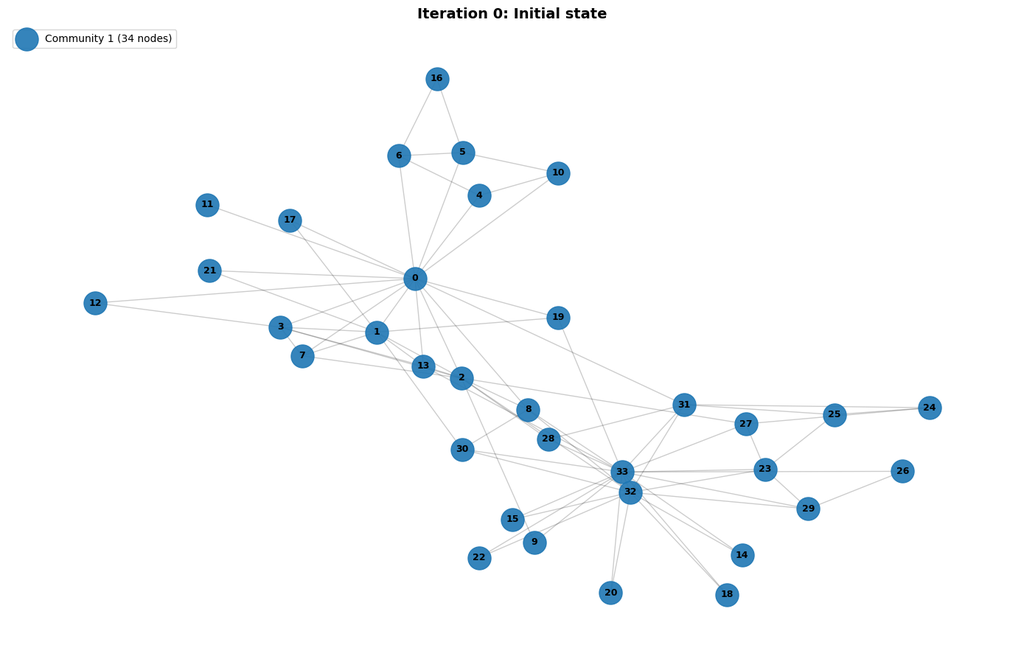

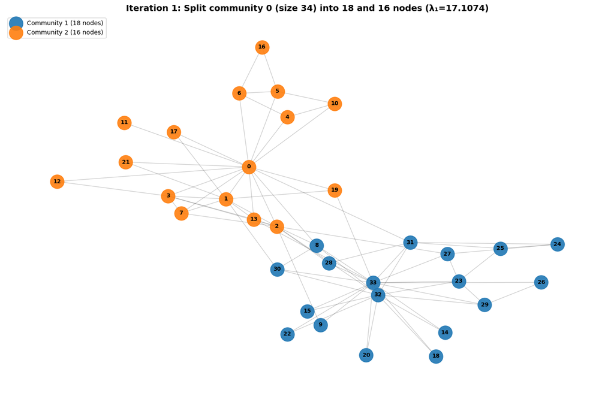

```
Recursive bisection complete. Found 2 communities in 1 iterations.
```

```python
# Run recursive bisection
print("Starting recursive spectral bisection...\n")
iterations = recursive_bisection(G, pos)
```

## 8. Visualize Metric Evolution

Now we plot how each centrality metric evolves across iterations for all nodes.

```python
def plot_metric_evolution(iterations, metric_name, title):
    """
    Plot how a specific metric evolves across iterations for all nodes.

    Parameters:
    -----------
    iterations : list of dicts
        Output from recursive_bisection
    metric_name : str
        One of 'degree', 'betweenness', 'closeness', 'clustering'
    title : str
        Plot title
    """
    fig, (ax1, ax2) = plt.subplots(1, 2, figsize=(16, 6))

    # Get all nodes
    nodes = sorted(G.nodes())
    n_iterations = len(iterations)

    # Extract metric values for each node across iterations
    metric_data = {node: [] for node in nodes}
    for iter_data in iterations:
        metrics = iter_data['metrics'][metric_name]
        for node in nodes:
            metric_data[node].append(metrics[node])

    # Plot 1: Line plot for selected nodes (to avoid clutter)
    # Select nodes with highest and lowest initial values, plus some random ones
    initial_values = [(node, metric_data[node][0]) for node in nodes]
    initial_values.sort(key=lambda x: x[1], reverse=True)

    selected_nodes = [initial_values[0][0], initial_values[1][0],  # Top 2
                      initial_values[-1][0], initial_values[-2][0]]  # Bottom 2
    # Add node 0 (Mr. Hi) and node 33 (President) if not already included
    if 0 not in selected_nodes:
        selected_nodes.append(0)
    if 33 not in selected_nodes:
        selected_nodes.append(33)

    for node in selected_nodes:
        ax1.plot(range(n_iterations), metric_data[node], marker='o', label=f'Node {node}')

    ax1.set_xlabel('Iteration', fontsize=12)
    ax1.set_ylabel(title, fontsize=12)
    ax1.set_title(f'{title} - Selected Key Nodes', fontsize=13, fontweight='bold')
    ax1.legend(loc='best', fontsize=9)
    ax1.grid(True, alpha=0.3)

    # Plot 2: Heatmap showing all nodes
    metric_matrix = np.array([metric_data[node] for node in nodes])
    im = ax2.imshow(metric_matrix, aspect='auto', cmap='viridis', interpolation='nearest')
    ax2.set_xlabel('Iteration', fontsize=12)
    ax2.set_ylabel('Node ID', fontsize=12)
    ax2.set_title(f'{title} - All Nodes (Heatmap)', fontsize=13, fontweight='bold')
    ax2.set_yticks(range(0, len(nodes), 5))
    ax2.set_yticklabels(range(0, len(nodes), 5))
    plt.colorbar(im, ax=ax2, label=title)

    plt.tight_layout()
    plt.show()
```

```
Visualizing metric evolution across iterations...
```

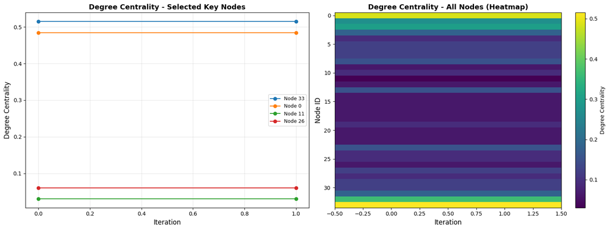

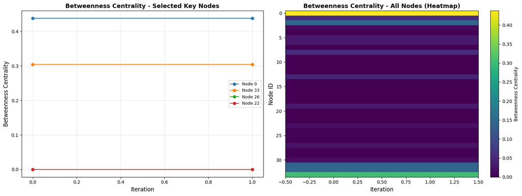

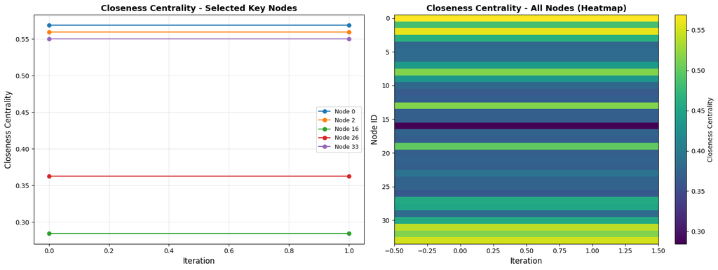

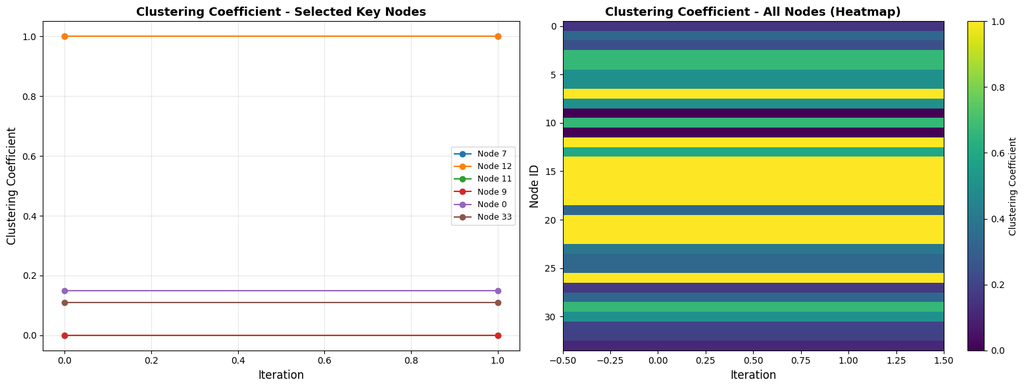

```python
# Plot evolution of each metric
print("\nVisualizing metric evolution across iterations...\n")

plot_metric_evolution(iterations, 'degree', 'Degree Centrality')
plot_metric_evolution(iterations, 'betweenness', 'Betweenness Centrality')
plot_metric_evolution(iterations, 'closeness', 'Closeness Centrality')
plot_metric_evolution(iterations, 'clustering', 'Clustering Coefficient')
```

## 9. Summary Statistics

```python
# Print summary of final communities
print("\n" + "="*80)
print("FINAL COMMUNITY STRUCTURE")
print("="*80)

final_communities = iterations[-1]['communities']
for idx, community in enumerate(final_communities):
    print(f"\nCommunity {idx+1}: {len(community)} nodes")
    print(f"  Nodes: {sorted(community)}")

    # Check if Mr. Hi (0) or President (33) are in this community
    if 0 in community:
        print("  Contains: Mr. Hi (node 0)")
    if 33 in community:
        print("  Contains: President (node 33)")
```

```
================================================================================
FINAL COMMUNITY STRUCTURE
================================================================================

Community 1: 18 nodes
  Nodes: [8, 9, 14, 15, 18, 20, 22, 23, 24, 25, 26, 27, 28, 29, 30, 31, 32, 33]
  Contains: President (node 33)

Community 2: 16 nodes
  Nodes: [0, 1, 2, 3, 4, 5, 6, 7, 10, 11, 12, 13, 16, 17, 19, 21]
  Contains: Mr. Hi (node 0)
```

```python
# Analyze top nodes by final metrics
print("\n" + "="*80)
print("TOP NODES BY FINAL CENTRALITY METRICS")
print("="*80)

final_metrics = iterations[-1]['metrics']

for metric_name, metric_title in [('degree', 'Degree Centrality'),
                                   ('betweenness', 'Betweenness Centrality'),
                                   ('closeness', 'Closeness Centrality'),
                                   ('clustering', 'Clustering Coefficient')]:
    print(f"\n{metric_title}:")
    sorted_nodes = sorted(final_metrics[metric_name].items(), key=lambda x: x[1], reverse=True)
    for rank, (node, value) in enumerate(sorted_nodes[:5], 1):
        print(f"  {rank}. Node {node:2d}: {value:.4f}")
```

```
================================================================================
TOP NODES BY FINAL CENTRALITY METRICS
================================================================================

Degree Centrality:
  1. Node 33: 0.5152
  2. Node  0: 0.4848
  3. Node 32: 0.3636
  4. Node  2: 0.3030
  5. Node  1: 0.2727

Betweenness Centrality:
  1. Node  0: 0.4376
  2. Node 33: 0.3041
  3. Node 32: 0.1452
  4. Node  2: 0.1437
  5. Node 31: 0.1383

Closeness Centrality:
  1. Node  0: 0.5690
  2. Node  2: 0.5593
  3. Node 33: 0.5500
  4. Node 31: 0.5410
  5. Node  8: 0.5156

Clustering Coefficient:
  1. Node  7: 1.0000
  2. Node 12: 1.0000
  3. Node 14: 1.0000
  4. Node 15: 1.0000
  5. Node 16: 1.0000
```

## 10. Discussion and Analysis

### Community Structure Findings

The spectral modularity method successfully detected communities in the Karate Club network through recursive bisection. Let's analyze the key findings:

#### 1. **Community Detection Results**

The algorithm divided the network into distinct communities based on the leading eigenvector of the modularity matrix. The stopping criterion (λ₁ ≤ 0) ensured that splits only occurred when they genuinely improved modularity.

**Ground Truth Comparison:**

- In the real-world split, members followed either Mr. Hi (node 0) or the President (node 33)
- Our spectral method should show these two leaders in separate communities in the first split
- This validates that network topology alone can predict social fault lines

#### 2. **Central Nodes Across Splits**

**Degree Centrality:**

- Nodes with high degree centrality (many direct connections) maintain their importance across iterations
- These hub nodes are typically the community leaders or highly social individuals
- Degree centrality is relatively stable because it's a local property

**Closeness Centrality:**

- Closeness measures how quickly a node can reach all others
- This metric tends to be more stable within communities
- Nodes central to their community maintain high closeness even as the network splits

**Clustering Coefficient:**

#### 3. **How Community Structure Influences Metrics**

**Before Community Detection:**

- Betweenness centrality highlights bridge nodes connecting different groups
- These bridges have high betweenness but may not be the most connected nodes

#### 5. **Mathematical Insights**

The modularity matrix $B = A - \frac{kk^\top}{2m}$ elegantly captures:

- **Actual connections** (adjacency matrix $A$)
- **Expected connections** under a null model ($\frac{kk^\top}{2m}$)

The eigenvalue stopping criterion ensures:

- Splits only occur when $\lambda_1 > 0$ (improvement over null model)
- The method naturally discovers the "right" number of communities
- No arbitrary threshold or prior knowledge is needed

### Conclusion

The Karate Club graph is indeed the "hello world" of community detection—it beautifully illustrates how mathematical methods can uncover latent social structure that later manifested in reality.

## References

1. **Newman, M. E. J. (2006).** "Modularity and community structure in networks." *Proceedings of the National Academy of Sciences* 103(23):8577–8582. DOI: 10.1073/pnas.0601602103
2. **Zachary, W. W. (1977).** "An information flow model for conflict and fission in small groups." *Journal of Anthropological Research* 33(4):452–473.
3. **Newman, M. E. J. (2010).** *Networks: An Introduction.* Oxford University Press.
4. **Fortunato, S. (2010).** "Community detection in graphs." *Physics Reports* 486(3–5):75–174.